# R Notebook

```r
getwd()
```

```
[1] "C:/Users/LENOVO/Desktop/Complejidad Computacional"
```

```r
setwd("C:/Users/LENOVO/Desktop/Complejidad Computacional")
```

```r
library(tidyverse)
library(ggplot2)
tiempos <- read_csv("test.csv")
colnames(tiempos)<- c("Algoritmo","Tiempo", "Size", "Comparaciones", "Intercambios", "Opt")
```

```r
burbuja <- tiempos %>% filter(Algoritmo=="burbuja")
burbujaDetalles <- burbuja %>% group_by(Size, Opt) %>% summarise(promedioT=mean(Tiempo),
               Promediointer=mean(Intercambios),
               Tmax=max(Tiempo),
               Tmin=min(Tiempo),
               Maxintercambios = max(Intercambios),
               Minintercambios = min(Intercambios),
               DesvTiempo = sd(Tiempo)
               )
```

```r
graficaDetalles <- function(nombre){
  nombre %>% ggplot(aes(Size, promedioT))+geom_point()+ stat_smooth(method="lm", se=FALSE, aes(colour="lineal")) +
stat_smooth(method="lm", se=FALSE, formula=y~poly(x,2), aes(colour="cuadrada"))
}
```

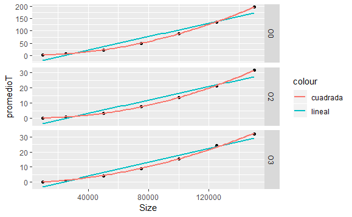

```r
graficaDetalles(burbujaDetalles)+ facet_grid(Opt ~ ., scale="free_y")
```

```r
modelo <- burbujaDetalles%>% filter(Opt=="O0")%>%lm(formula=promedioT ~ poly(Size,2), .)
summary(modelo)
```

```
Call:
lm(formula = promedioT ~ poly(Size, 2), data = .)

Residuals:
       1        2        3        4        5        6        7
-0.11498  0.07821  0.07630  0.15370 -0.22009 -0.07331  0.10016

Coefficients:
                Estimate Std. Error t value Pr(>|t|)
(Intercept)     71.57907    0.06342  1128.6 3.70e-12 ***
poly(Size, 2)1 175.23718    0.16780  1044.3 5.04e-12 ***
poly(Size, 2)2  43.41036    0.16780   258.7 1.34e-09 ***
---
Signif. codes:  0 *** 0.001 ** 0.01 * 0.05 . 0.1   1

Residual standard error: 0.1678 on 4 degrees of freedom
Multiple R-squared:      1, Adjusted R-squared:      1
F-statistic: 5.788e+05 on 2 and 4 DF,  p-value: 1.194e-11
```

```r
modelo <- burbujaDetalles%>% filter(Opt=="O2")%>%lm(formula=promedioT ~ poly(Size,2), .)
summary(modelo)
```

```
Call:
lm(formula = promedioT ~ poly(Size, 2), data = .)

Residuals:
       1        2        3        4        5        6        7
-0.08932  0.01791  0.06317  0.21534 -0.05378 -0.38054  0.22721

Coefficients:
               Estimate Std. Error t value Pr(>|t|)
(Intercept)    11.24547    0.09599  117.15 3.18e-08 ***
poly(Size, 2)1 27.97590    0.25397  110.16 4.07e-08 ***
poly(Size, 2)2  7.36914    0.25397   29.02 8.40e-06 ***
---
Signif. codes:  0 *** 0.001 ** 0.01 * 0.05 . 0.1   1

Residual standard error: 0.254 on 4 degrees of freedom
Multiple R-squared:  0.9997,    Adjusted R-squared:  0.9995
F-statistic:  6488 on 2 and 4 DF,  p-value: 9.496e-08
```

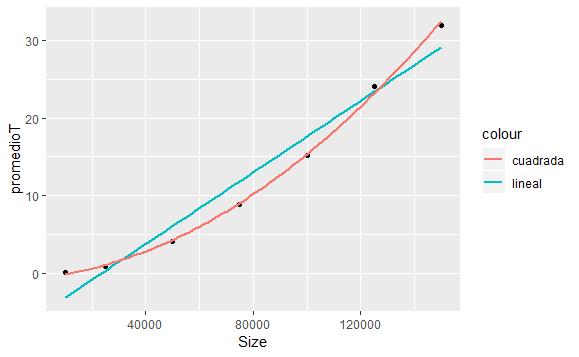

```r
burbujaDetalles %>% filter(Opt=="O3") %>% ggplot(aes(Size, promedioT))+geom_point()+ stat_smooth(method="lm", se=FALSE, aes(colour="lineal")) +
stat_smooth(method="lm", se=FALSE, formula=y~poly(x,2), aes(colour="cuadrada"))
```

```r
modelo <- burbujaDetalles%>% filter(Opt=="O3")%>%lm(formula=promedioT ~ poly(Size,2), .)
summary(modelo)
```

```
Call:
lm(formula = promedioT ~ poly(Size, 2), data = .)

Residuals:
      1       2       3       4       5       6       7
 0.2804 -0.1473 -0.2433 -0.1810 -0.1353  0.9533 -0.5267

Coefficients:
               Estimate Std. Error t value Pr(>|t|)
(Intercept)     12.1676     0.2233   54.48  6.8e-07 ***
poly(Size, 2)1  29.2076     0.5909   49.43  1.0e-06 ***
poly(Size, 2)2   6.0745     0.5909   10.28 0.000505 ***
---
Signif. codes:  0 *** 0.001 ** 0.01 * 0.05 . 0.1   1

Residual standard error: 0.5909 on 4 degrees of freedom
Multiple R-squared:  0.9984,    Adjusted R-squared:  0.9976
F-statistic:  1274 on 2 and 4 DF,  p-value: 2.455e-06
```

$r^2$ optimización O0 regresion lineal 0.9422 $r^2$ optimización O2 regresion lineal 0.9348 $r^2$ optimización O3 regresion lineal 0.957

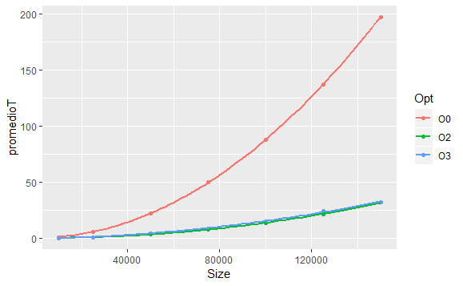

```r
burbujaDetalles %>% ggplot(aes(Size, promedioT, col=Opt))+geom_point()+
stat_smooth(method="lm", se=FALSE, formula=y~poly(x,2))
```

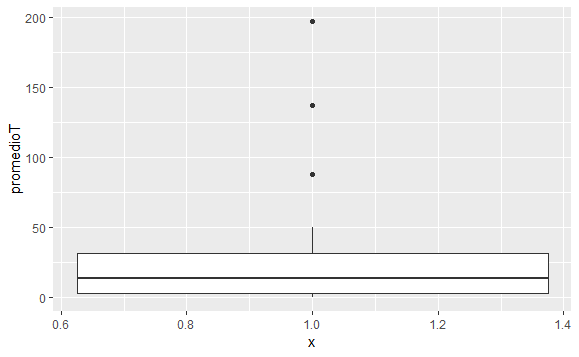

```r
burbujaDetalles %>% ggplot(aes(1,promedioT))+geom_boxplot()
```

```r
quicksort <- tiempos %>% filter(Algoritmo=="quicksort")
```

```r
quicksortDetalles <- quicksort %>% group_by(Size, Opt) %>% summarise(promedioT=mean(Tiempo),
               Promediointer=mean(Intercambios),
               Tmax=max(Tiempo),
               Tmin=min(Tiempo),
               Maxintercambios = max(Intercambios),
               Minintercambios = min(Intercambios),
               DesvTiempo = sd(Tiempo)
               )
```

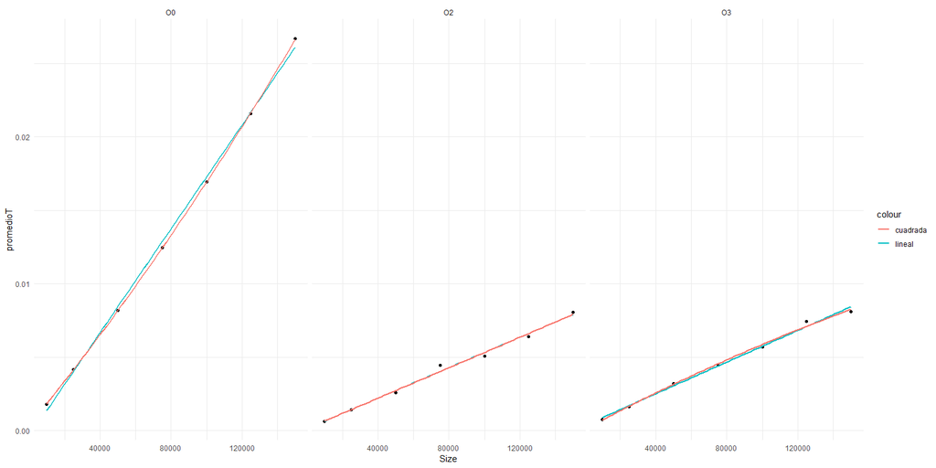

```r
graficaDetalles(quicksortDetalles)+facet_wrap(~Opt)+theme_minimal()
```

```r
summary(modelo)
```

[output not shown]

$r^2$ optimización O0 regresion lineal 0.9982 $r^2$ optimización O2 regresion lineal 0.9924 $r^2$ optimización O3 regresion lineal 0.994 quicksort $r^2$ optimización o0 regresion polinomial grado 2 1 $r^2$ optimización O2 regresion polinomial grado 2 0.9924 $r^2$ optimización O3 regresion polinomial grado 2 0.9963

```r
radix <- tiempos %>% filter(Algoritmo=="radix")
radixDetalles <- radix %>% group_by(Size, Opt) %>% summarise(promedioT=mean(Tiempo),
               Promediointer=mean(Intercambios),
               Tmax=max(Tiempo),
               Tmin=min(Tiempo),
               Maxintercambios = max(Intercambios),
               Minintercambios = min(Intercambios),
               DesvTiempo = sd(Tiempo)
               )
```

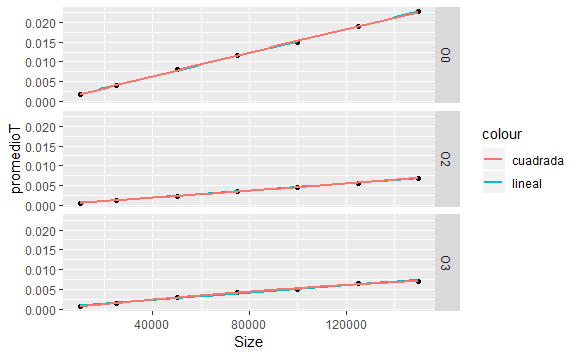

```r
summary(modelo)
```

[output not shown]

$r^2$ optimización O0 regresion lineal 0.9996 $r^2$ optimización O2 regresion lineal 0.999 $r^2$ optimización O3 regresion lineal 0.9877 radix $r^2$ optimización o0 regresion polinomial grado 2 0.9996 $r^2$ optimización O2 regresion polinomial grado 2 0.9994 $r^2$ optimización O3 regresion polinomial grado 2 0.9953

————————COMPARACIONES ————————————- BURBUJA

```r
burbuja %>% group_by(Size) %>% summarise(meancambios=mean(Comparaciones)) %>% ggplot(aes(Size,meancambios))+ geom_point()+ stat_smooth(method="lm", se=FALSE, formula=y ~ poly(x,2))
```

[output not shown]

```r
modelo<- burbuja %>% group_by(Size)%>% summarise(meancambios=mean(Comparaciones)) %>% lm(formula=meancambios ~ poly(Size,2),.)
summary(modelo)
```

[output not shown]

$r^2=1$

QUICKSORT

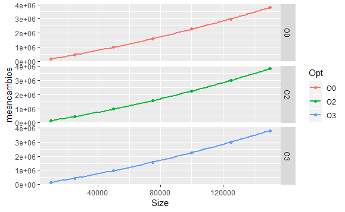

Radix

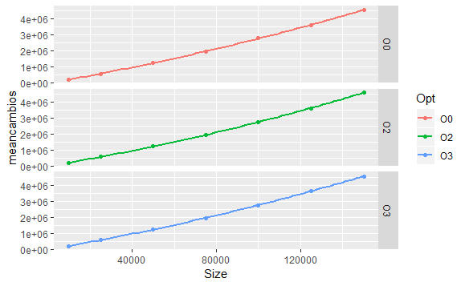

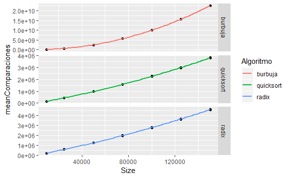

quicksort es el que hace menos comparaciones, con un máximo de 4124615 para un vector de tamaño 150000, radix cuenta con un número maximo de comparaciones de 4874610 para un vector de tamaño 150000, y por último burbuja, el número máximo de comparaciones es 22499700001 (22 mil 499 millones)

————————-INTERCAMBIOS————————————– Burbuja

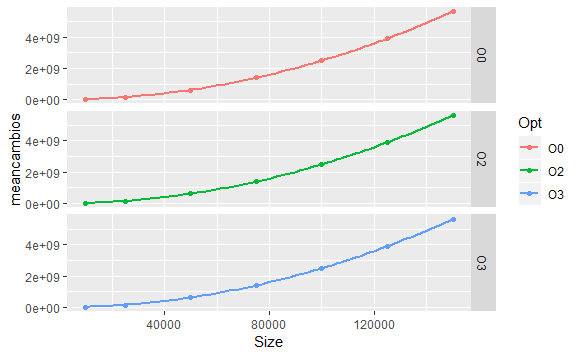

```r
summary(modelo)
```

[output not shown]

$R^2=0.9416$ lineal $R^2=1$ segundo grado

quicksort

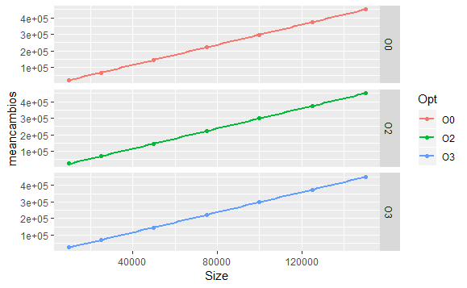

```r
summary(modelo)
```

[output not shown]

$R^2$ = 1

Radix

```r
radix %>% group_by(Size,Opt) %>% summarise(meancambios=mean(Intercambios)) %>% ggplot(aes(Size,meancambios, col=Opt))+ geom_point()+ stat_smooth(method="lm", se=FALSE, formula=y ~ x) + facet_grid(Opt~.)
```

[output not shown]

```r
modelo<- radix %>% group_by(Size,Opt) %>% summarise(meancambios=mean(Intercambios)) %>% lm(formula=meancambios~Size)
summary(modelo)
```

[output not shown]

$r^2=1$ comportamiento lineal

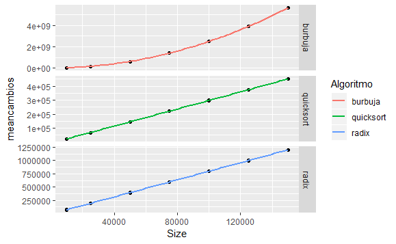

quicksort es el que hace menos intercambios, con un maximo de 456598 para un vector de tamaño 150000, radix cuenta con un número maximo de intercambios de 1206598 para un vector de tamaño 150000, y por último burbuja, el número máximo de intercambios es 5654648782 (5 mil 600 millones)